# Used_Cars Dataset Exploration

#### I will look at how seller_type affects the relationship between selling price and max_power

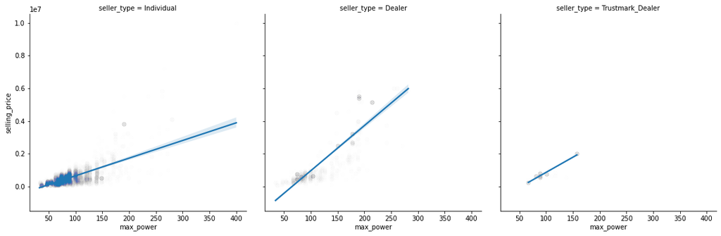

```python
g = sb.FacetGrid(data = used_cars, col = 'seller_type', col_wrap = 3)
g.map(sb.regplot,'max_power', 'selling_price', x_jitter = 0.05, scatter_kws = {'alpha': 0.005});
plt.gcf().set_size_inches(16, 6)
```

#### I would like to see how Transmission affects Selling Price over Owner.

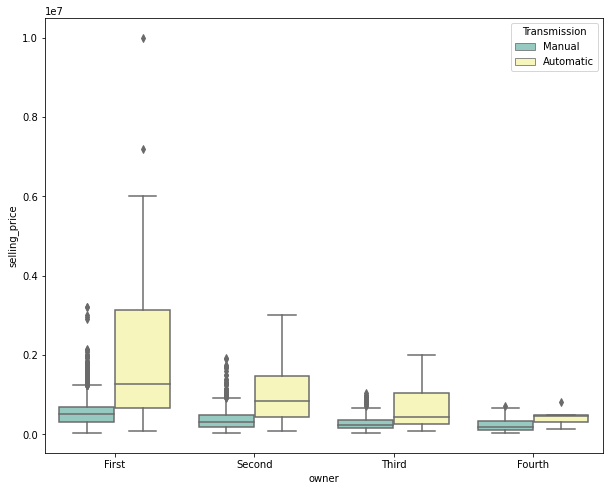

```python
fig = plt.figure(figsize = [10, 8])
ax = sb.boxplot(x='owner', y='selling_price', hue='transmission',
                 data=used_cars, palette="Set3")
plt.legend(title = 'Transmission');
```

> it could be seen from above plot that as the order of owner moves from first to fourth, selling price deacreases as well as automatics used cars. there is no significant effects on manual cars.

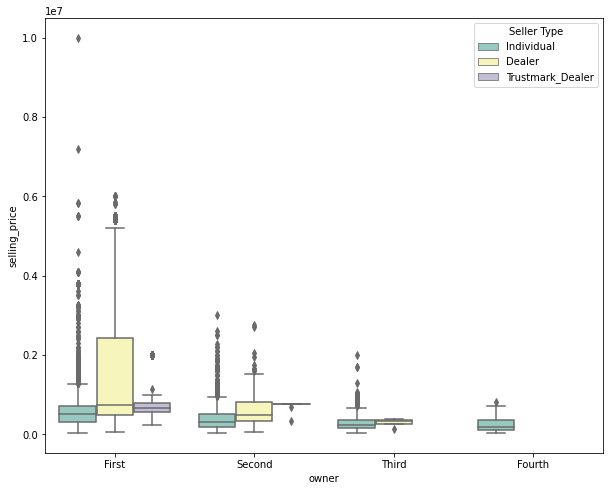

```python
fig = plt.figure(figsize = [10, 8])
ax = sb.boxplot(x='owner', y='selling_price', hue='seller_type',
                 data=used_cars, palette="Set3")
plt.legend(title = 'Seller Type');
```

> there is no much overall seller effect on the relationship between owner and selling price. however, DEALERs enlistes used cars are more expensive than used cars enlisted by Individual across the order from first to third as the used cars of fourth onwer are enlisted for sale by only Individual.

### Talk about some of the relationships you observed in this part of the investigation. Were there features that strengthened each other in terms of looking at your feature(s) of interest?

> Individual owner has effect on relationship between selling_price and max_power. this show that owner has a strong positive relationship with selling price and car maximum power. first owner car are the most expensive followed by the second, then third and fouth. The purchase year also determine the selling price as recent purchase cars are first owned and more expensive than older purchase year.

### Were there any interesting or surprising interactions between features?

> No

## Conclusions

> maximum power, purchase year, and transmission has strong effect on the selling price of used cars, hecnce can be used to predict the selling price of used cars in USA across the city the data was collected.